# Homework 3: $K$-Nearest Neighbors

Author

Shea, Shifa, Shubha

# Introduction

In this homework, you will practice applying the $K$-Nearest Neighbors (KNN) method which is capable of performing both classification and regression. You will also practice collaborating with a team over GitHub.

## Learning goals

By the end of the homework, you will…

- Be able to work simultaneously with teammates on the same document using GitHub
- Fit and interpret KNN models in both regression and classification settings
- Compare and evaluate different KNN models

# Getting Started

In last weeks homework, you learned how to share your work using GitHub but only while working on the same document at different times. This week we will learn how to work on the same document *simultaneously*.

## Teams & Rules

You can find your team for this assignment on Canvas in the **People** section. The group set is called **HW3**. Your group will consist of 2-3 people and has been randomly generated. But first, some rules:

1. You and your team members should be in the same physical room for Exercises 0.1 and 0.2. After that, you are welcome to divide up the work as you see fit. Please note that most of these problems have to be done sequentially except for Exercises 10-12, which can be done apart from 1-9.
2. You are all responsible for understanding the work that you turn in.
3. In order to receive credit, each team member but make a roughly equal contribution. Since this project has 12 exercises (not including 0), each team member should commit and push at least 4 different exercises.
4. If you are working on the same document simultaneously, make sure to render, commit, push, and pull FREQUENTLY.
5. If you encounter a merge error that you don’t know how to fix, contact Dr. Friedlander as soon as possible. I recommend starting this assignment early so there is time for Dr. Friedlander to help you resolve any problems before the deadline.

## Clone the repo & start new RStudio project

The following directions will guide you through the process of setting up your homework to work as a group.

## Exercise 0.1

**Question**

In your group, decide on a team name. Then have **one member of your group**:

1. [Click this link](https://classroom.github.com/a/LEbjScjp) to accept the assignment and enter your team name.
2. Repeat the directions for creating a project from HW 1 with the HW 3 repository.

Once this is complete, the other members can do the same thing, being careful to join the already created team on GitHub classroom.

## Exercise 0.2

We will now learn how to collaborate on the same document at the same time by creating a **merge conflict**. You can read more about it [here](https://happygitwithr.com/pull-tricky#pull-tricky) and [here](https://happygitwithr.com/git-branches.html?q=merge#merging-a-branch).

**Question**

1. Have Members 1, 2, and 3 all create write different team names below and Render the document.
2. Have Member 1 add, commit, and push changes.
3. Have Member 2 add, commit, and push changes. This should cause an error.
4. Have Member 2 pull changes from the remote repo which should generate something like this: `CONFLICT (content): Merge conflict in 03-hw-knn.qmd`.
5. Have Member 2 open the `.qmd` file. You should see something like the third block of code in Section 22.4 of [this link](https://happygitwithr.com/git-branches.html?q=merge#merging-a-branch).
6. Have Member edit the document so that it has only their team name, then render, commit, and push. This should not cause an error.
7. Have Member 3 repeat steps 3-6.
8. Agree on what you want your team name to actually be and have Member 1 repeat steps 3-6.
9. Note that you will only generate a merge conflict if you make edits to the same line of code. If you are working on the same document simultaneously but are editing different portions, git should automatically merge for you.
- Team Name: [she-shu-shi]
- Member 1: [Shea]
- Member 2: [Shifa]
- Member 3: [Shubha]

# $K$-Nearest Neighbors

The basic idea is that predictions are made based on the $K$ observation in the training data which are “closest” to the observation that we’re making a prediction for. While many different **metrics** (i.e. measures of distance) can be used, we will work exclusively with the **Euclidean metric**:
$$\text{dist}(x, y) = \sqrt{\sum_{i=1}^p(x_i-y_i)^2}$$
for vectors $x = (x_1,\ldots, x_p)$ and $y = (y_1,\ldots,y_p)$.

## KNN for Classification

We’ll start by using KNN for classification.

## Data

We will be working with the famous `iris` data set which consists of four measurements (in centimeters) for 150 plants belonging to three species of iris. This data set was first published in a classic 1936 paper by English statistician, and notable racist/eugenicist, Ronald Fisher. In that paper, multivariate linear models were applied to classify these plants. Of course, back then, model fitting was an extremely laborious process that was done without the aid of calculators or statistical software.

## Exercise 1

**Question**

Import the `datasets` package, take a look at the columns of `iris`, and split your data into training and test sets using a 70-30 split. IMPORTANT: Make sure that each species is represented proportionally in the training set by using the `strata` argument in the `initial_split` function! Once again, set your seed to 427.

```r
library("datasets")
library("tidymodels")

set.seed(427)

iris_split <- initial_split(iris, prop = .7, strata = Species)


iris_split
```

```
<Training/Testing/Total>
<105/45/150>
```

```r
iris_train <- training(iris_split)
iris_test <- testing(iris_split)

# iris_train
# iris_test
# data(iris)
# summary(iris)
```

## Exercise 2

**Question**

Create a scatter plot of your training set with `Sepal.Width` and `Petal.Width` on the x- and y- axes, respectively, and color the points by `Species`.

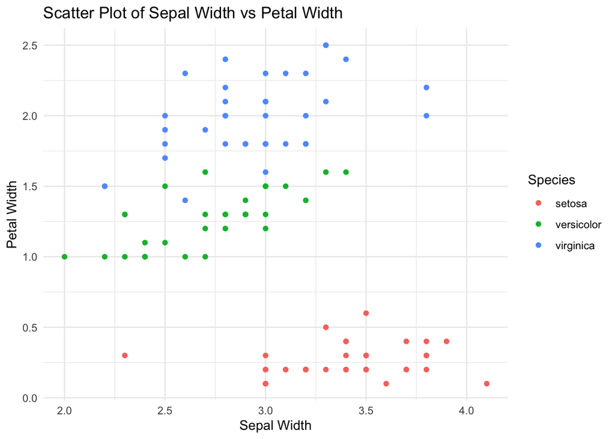

```r
ggplot(iris_train, aes(x = Sepal.Width, y = Petal.Width, color = Species)) +
  geom_point() +
  labs(
    title = "Scatter Plot of Sepal Width vs Petal Width",
    x = "Sepal Width",
    y = "Petal Width"
  ) +
  theme_minimal()
```

## Exercise 3

**Question**

As the name suggests, the $K$-nearest neighbors (KNN) method classifies a point based on the classification of the observations in the training set that are nearest to that point. If $k > 1$, then the neighbors essentially “vote” on the classification of the point. Using only your graph, if $k = 1$, how would KNN classify a flower that had sepal width 3cm and petal width 1cm?

## Exercise 4

**Question**

Just to verify that we are correct, find the sepal width, petal width, and species of the observation in your training set that is closest to our flower with sepal width 3cm and petal width 1cm. This should be done by computing the Euclidean distance of (3, 1) to each observation and then sorting the resulting tibble to get the row with the smallest distance. Don’t worry about normalizaing the data.

```r
new_flower <- c(3, 1)

iris_train_check <- iris_train |>
  mutate(distance = sqrt((Sepal.Width - new_flower[1])^2 + (Petal.Width - new_flower[2])^2))

closest_observation <- iris_train_check |>
  arrange(distance) |>
  slice(1) |>
  select(Sepal.Width, Petal.Width, Species, distance)

print(closest_observation)
```

```
  Sepal.Width Petal.Width    Species distance
1           3         1.2 versicolor      0.2
```

## Exercise 5

**Question**

Create a `recipe` to center and scale your data sets using the mean and standard deviation from your training set.

```r
recipe_train <- recipe(Species ~ ., data = iris_train) |>
  step_center(all_predictors()) |>
  step_scale(all_predictors())

#prepare the recipe
prepped_train_recipe <- prep(recipe_train, training = iris_train)

# applying to training set
iris_train_prepped <- bake(prepped_train_recipe, new_data = iris_train)

iris_train_prepped
```

```
# A tibble: 105 × 5
   Sepal.Length Sepal.Width Petal.Length Petal.Width Species
          <dbl>       <dbl>        <dbl>       <dbl> <fct>
 1       -0.877      1.07          -1.33       -1.32 setosa
 2       -1.12      -0.0715        -1.33       -1.32 setosa
 3       -1.37       0.383         -1.39       -1.32 setosa
 4       -1.49       0.156         -1.27       -1.32 setosa
 5       -0.508      1.98          -1.16       -1.05 setosa
 6       -1.49       0.838         -1.33       -1.18 setosa
 7       -1.00       0.838         -1.27       -1.32 setosa
 8       -0.508      1.52          -1.27       -1.32 setosa
 9       -1.25      -0.0715        -1.33       -1.45 setosa
10       -1.86      -0.0715        -1.50       -1.45 setosa
# ℹ 95 more rows
```

## Exercise 6

**Question**

Create a `workflow` to fit a KNN model that uses `weight_func = "rectangular"` with 1 neighbor that includes the recipe above and fit the model to your training set.

```r
knn1model <- nearest_neighbor(mode = "classification",
                          engine = "kknn",
                          neighbors = 1,
                          weight_func = "rectangular")

knn1_fit <- workflow() |>
  add_model(knn1model) |>
  add_recipe(recipe_train) |>
  fit(data = iris_train_prepped)

knn1_fit
```

```
══ Workflow [trained] ══════════════════════════════════════════════════════════
Preprocessor: Recipe
Model: nearest_neighbor()

── Preprocessor ────────────────────────────────────────────────────────────────
2 Recipe Steps

• step_center()
• step_scale()

── Model ───────────────────────────────────────────────────────────────────────

Call:
kknn::train.kknn(formula = ..y ~ ., data = data, ks = min_rows(1,     data, 5), kernel = ~"rectangular")

Type of response variable: nominal
Minimal misclassification: 0.0952381
Best kernel: rectangular
Best k: 1
```

```r
 g1 <- rep((200:450)*(1/100), 250)
 g2 <- rep((0:250)*(1/100), each = 250)
 grid <- tibble(Sepal.Width = g1, Petal.Width = g2)
 grid
```

```
# A tibble: 62,750 × 2
   Sepal.Width Petal.Width
         <dbl>       <dbl>
 1        2              0
 2        2.01           0
 3        2.02           0
 4        2.03           0
 5        2.04           0
 6        2.05           0
 7        2.06           0
 8        2.07           0
 9        2.08           0
10        2.09           0
# ℹ 62,740 more rows
```

## Exercise 7

**Question**

Uncomment the code above, and change the variable names so that it will work with your model. Classify the points in `grid` using your training data and $k = 1$. Then, plot the points in `grid` colored by their classification. Make sure your code is written so that the grid points are being centered and scaled before predictions are being made for them.

```r
#mean values
grid_filled <- grid |>
  mutate(Sepal.Length = mean(iris_train$Sepal.Length),
         Petal.Length = mean(iris_train$Petal.Length))

#applying the same scaling
grid_prepped <- bake(prepped_train_recipe, new_data = grid_filled)

#predict classes for the grid points
grid_predictions <- predict(knn1_fit, new_data = grid_prepped)

#Combine predictions with the grid
grid_with_predictions <- bind_cols(grid, grid_predictions)
```

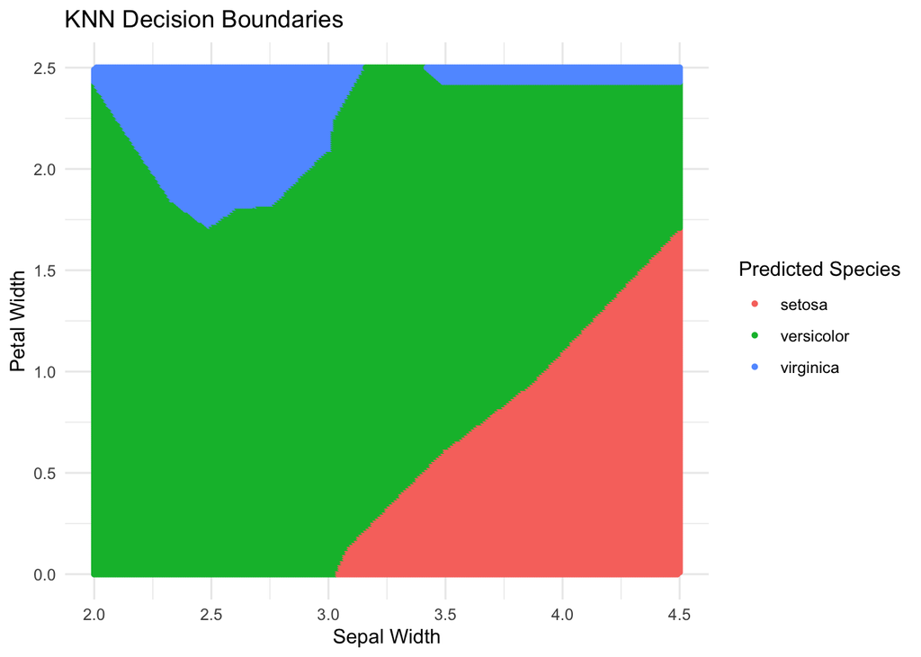

```r
#ploting decision boundaries
ggplot(grid_with_predictions, aes(x = Sepal.Width, y = Petal.Width, color = .pred_class)) +
  geom_point(size = 1) +
  labs(title = "KNN Decision Boundaries",
       x = "Sepal Width",
       y = "Petal Width",
       color = "Predicted Species") +
  theme_minimal()
```

## Exercise 8

**Question**

Notice that the decision boundary between `versicolor` and `virginica` looks a little strange. What do you observe? Why do you think this is happening? Does using $k = 2$ make things better or worse? Why do you think that is?

- The boundary looks irregular, most likely due to k=1 since every point is classified based solely on its nearest neighbor.
- The boundary’s very sensitive to noise where small fluctuations in the training data can lead to it being non-smooth and irregular. This classifies as model over-fitting.
- When k=2, we would expect the boundary to be smoother and less irregular since instead of just one nearest neighbor, the classification decision will be based on two.

## Exercise 9

**Question**

Determine which value of $k$, the number of neighbors selected, gives the highest accuracy on the test set. Test all $k$s between 1 and 40. Note that there may be ties because our data set is a little bit too small. To break ties just choose the smallest $k$ among the ones which are tied. Hint: A for loop may be helpful. What is the accuracy of the model you ended up choosing?

```r
set.seed(427)

k_values <- 1:40

knn_results <- tibble(k = integer(), Accuracy = numeric())

for (k in k_values) {

  knn_model <- nearest_neighbor(
    mode = "classification",
    neighbors = k
  ) |>
    set_engine("kknn") |>
    fit(Species ~ Sepal.Width + Petal.Width, data = iris_train)

  predictions <- predict(knn_model, new_data = iris_test) |>
    bind_cols(iris_test)

  accuracy <- mean(predictions$.pred_class == predictions$Species)

  knn_results <- bind_rows(knn_results, tibble(k = k, Accuracy = accuracy))
}

best_k <- knn_results |>
  filter(Accuracy == max(Accuracy)) |>
  slice_min(k) |>
  pull(k)

best_accuracy <- max(knn_results$Accuracy)

best_k
```

```
[1] 4
```

```r
best_accuracy
```

```
[1] 0.9555556
```

Awesome!! Your model probably did pretty well, because KNN performs really well on the `iris` data set. However, this isn’t a very challenging data set for most classification methods. More challenging data sets have data on different scales and *class imbalance* where there are very few observations belonging to a particular class.

# KNN for Regression

For regression, we can predict the response variable for our point to be the average (or sometimes median) of the response variable for the $K$-nearest neighbors.

## Data & Dummy Variables

For this portion of the homework, we’ll use the `Carseat` data from the `ISLR2` package. Frequently, when working with categorical data, you will be required to transform that data into **dummy variables**. Namely, you’ll create a unique variable for each column which gets a 1 if the corresponding observation is from that category and a 0 otherwise. In data science, this format is sometimes referred to as **one-hot encoding**.

## Exercise 10

**Question**

Look at the `Carseat` data from the `ISLR2` package. Then, split the data into a training and test set using a 70-30 split and a seed of 427 (as usual).

```r
library("ISLR2")

set.seed(427)

car_split <- initial_split(Carseats, prop = .7)

car_split
```

```
<Training/Testing/Total>
<280/120/400>
```

```r
glimpse(car_split)
```

```
List of 4
 $ data  :'data.frame': 400 obs. of  11 variables:
  ..$ Sales      : num [1:400] 9.5 11.22 10.06 7.4 4.15 ...
  ..$ CompPrice  : num [1:400] 138 111 113 117 141 124 115 136 132 132 ...
  ..$ Income     : num [1:400] 73 48 35 100 64 113 105 81 110 113 ...
  ..$ Advertising: num [1:400] 11 16 10 4 3 13 0 15 0 0 ...
  ..$ Population : num [1:400] 276 260 269 466 340 501 45 425 108 131 ...
  ..$ Price      : num [1:400] 120 83 80 97 128 72 108 120 124 124 ...
  ..$ ShelveLoc  : Factor w/ 3 levels "Bad","Good","Medium": 1 2 3 3 1 1 3 2 3 3 ...
  ..$ Age        : num [1:400] 42 65 59 55 38 78 71 67 76 76 ...
  ..$ Education  : num [1:400] 17 10 12 14 13 16 15 10 10 17 ...
  ..$ Urban      : Factor w/ 2 levels "No","Yes": 2 2 2 2 2 1 2 2 1 1 ...
  ..$ US         : Factor w/ 2 levels "No","Yes": 2 2 2 2 1 2 1 2 1 2 ...
 $ in_id : int [1:280] 258 213 3 61 70 289 75 297 36 400 ...
 $ out_id: logi NA
 $ id    : tibble [1 × 1] (S3: tbl_df/tbl/data.frame)
  ..$ id: chr "Resample1"
 - attr(*, "class")= chr [1:3] "initial_split" "mc_split" "rsplit"
```

```r
car_train <- training(car_split)
car_test <- testing(car_split)
```

## Exercise 11

**Question**

Create a recipe which first, converts all categorical variables into dummy variables using `step_dummy()` then centers and scales all of the predictors based on the training data.

```r
library(knitr)
carseat_folds <- vfold_cv(data = car_train, v = 10)

car_rec_preproc <- recipe(Sales ~ .,data=car_train) |>
  step_unknown() |>
  step_dummy(all_nominal_predictors(), one_hot = TRUE) |>
  step_zv(all_predictors()) |>
  step_normalize(all_predictors())
```

## Exercise 12

**Question**

Fit a KNN model to predict `Sales` from the data we have. Fit your model on the training data and use the test set to choose the appropriate variables and the number of neighbors to include. You may find it useful to plot the $R^2$ and RMSE against the number of neighbors you include in your model. You may find that the RMSE and $R^2$ disagree on what the best model is. You will have to make a judgement call on which model is “best”. One thing that can be helpful is looking at plots of your target variables (`Sales` in this case) against the model residuals.

```r
library(class)
set.seed(427)



# l = list()
#
# for (k in (1:10)){
#
#   knn_m <- nearest_neighbor(neighbors = k) |>
#     set_engine("kknn") |>
#     set_mode("regression")
#   knn_mwf <- workflow() |> add_model(knn_m) |> add_recipe(car_rec_preproc)
#
#   append(l,knn_mwf)
#
#   knn_mwf
# }



knn1_m <- nearest_neighbor(neighbors = 1) |>
    set_engine("kknn") |>
    set_mode("regression")
  knn_mwf1 <- workflow() |> add_model(knn1_m) |> add_recipe(car_rec_preproc)

knn2_m <- nearest_neighbor(neighbors = 2) |>
    set_engine("kknn") |>
    set_mode("regression")
  knn_mwf2 <- workflow() |> add_model(knn2_m) |> add_recipe(car_rec_preproc)

knn3_m <- nearest_neighbor(neighbors = 3) |>
    set_engine("kknn") |>
    set_mode("regression")
  knn_mwf3 <- workflow() |> add_model(knn3_m) |> add_recipe(car_rec_preproc)

knn4_m <- nearest_neighbor(neighbors = 4) |>
    set_engine("kknn") |>
    set_mode("regression")
  knn_mwf4 <- workflow() |> add_model(knn4_m) |> add_recipe(car_rec_preproc)

knn5_m <- nearest_neighbor(neighbors = 5) |>
    set_engine("kknn") |>
    set_mode("regression")
  knn_mwf5 <- workflow() |> add_model(knn5_m) |> add_recipe(car_rec_preproc)

knn6_m <- nearest_neighbor(neighbors = 6) |>
    set_engine("kknn") |>
    set_mode("regression")
  knn_mwf6 <- workflow() |> add_model(knn6_m) |> add_recipe(car_rec_preproc)

knn7_m <- nearest_neighbor(neighbors = 7) |>
    set_engine("kknn") |>
    set_mode("regression")
  knn_mwf7 <- workflow() |> add_model(knn7_m) |> add_recipe(car_rec_preproc)

knn8_m <- nearest_neighbor(neighbors = 8) |>
    set_engine("kknn") |>
    set_mode("regression")
  knn_mwf8 <- workflow() |> add_model(knn8_m) |> add_recipe(car_rec_preproc)

knn9_m <- nearest_neighbor(neighbors = 9) |>
    set_engine("kknn") |>
    set_mode("regression")
  knn_mwf9 <- workflow() |> add_model(knn9_m) |> add_recipe(car_rec_preproc)

knn10_m <- nearest_neighbor(neighbors = 10) |>
    set_engine("kknn") |>
    set_mode("regression")
  knn_mwf10 <- workflow() |> add_model(knn10_m) |> add_recipe(car_rec_preproc)


carseat_metric <- metric_set(rmse,rsq)


knn_1res <- knn_mwf1 |> fit_resamples(resamples = carseat_folds, metrics = carseat_metric)

knn_2res <- knn_mwf2 |> fit_resamples(resample = carseat_folds, metrics = carseat_metric)

knn_3res <- knn_mwf3 |> fit_resamples(resample = carseat_folds, metrics = carseat_metric)

knn_4res <- knn_mwf4 |> fit_resamples(resample = carseat_folds, metrics = carseat_metric)

knn_5res <- knn_mwf5 |> fit_resamples(resample = carseat_folds, metrics = carseat_metric)

knn_6res <- knn_mwf6 |> fit_resamples(resample = carseat_folds, metrics = carseat_metric)

knn_7res <- knn_mwf7 |> fit_resamples(resample = carseat_folds, metrics = carseat_metric)

knn_8res <- knn_mwf8 |> fit_resamples(resample = carseat_folds, metrics = carseat_metric)

knn_9res <- knn_mwf9 |> fit_resamples(resample = carseat_folds, metrics = carseat_metric)

knn_10res <- knn_mwf10 |> fit_resamples(resample = carseat_folds, metrics = carseat_metric)

#had to start from 0 because the way the graph groups "workflow#" differently from "workflow##"

m1 <- collect_metrics(knn_1res) |> mutate(workflow = "Workflow0")
m2 <- collect_metrics(knn_2res) |> mutate(workflow = "Workflow1")
m3 <- collect_metrics(knn_3res) |> mutate(workflow = "Workflow2")
m4 <- collect_metrics(knn_4res) |> mutate(workflow = "Workflow3")
m5 <- collect_metrics(knn_5res) |> mutate(workflow = "Workflow4")
m6 <- collect_metrics(knn_6res) |> mutate(workflow = "Workflow5")
m7 <- collect_metrics(knn_7res) |> mutate(workflow = "Workflow6")
m8 <- collect_metrics(knn_8res) |> mutate(workflow = "Workflow7")
m9 <- collect_metrics(knn_9res) |> mutate(workflow = "Workflow8")
m10 <- collect_metrics(knn_10res) |> mutate(workflow = "Workflow9")
```

```r
all_metric <- bind_rows(m1,m2,m3,m4,m5,m6,m7,m8,m9,m10)
all_metric
```

```
# A tibble: 20 × 7
   .metric .estimator  mean     n std_err .config              workflow
   <chr>   <chr>      <dbl> <int>   <dbl> <chr>                <chr>
 1 rmse    standard   2.47     10  0.110  Preprocessor1_Model1 Workflow0
 2 rsq     standard   0.372    10  0.0420 Preprocessor1_Model1 Workflow0
 3 rmse    standard   2.30     10  0.113  Preprocessor1_Model1 Workflow1
 4 rsq     standard   0.420    10  0.0420 Preprocessor1_Model1 Workflow1
 5 rmse    standard   2.17     10  0.112  Preprocessor1_Model1 Workflow2
 6 rsq     standard   0.459    10  0.0417 Preprocessor1_Model1 Workflow2
 7 rmse    standard   2.10     10  0.112  Preprocessor1_Model1 Workflow3
 8 rsq     standard   0.483    10  0.0415 Preprocessor1_Model1 Workflow3
 9 rmse    standard   2.06     10  0.114  Preprocessor1_Model1 Workflow4
10 rsq     standard   0.497    10  0.0420 Preprocessor1_Model1 Workflow4
11 rmse    standard   2.03     10  0.117  Preprocessor1_Model1 Workflow5
12 rsq     standard   0.506    10  0.0433 Preprocessor1_Model1 Workflow5
13 rmse    standard   2.02     10  0.119  Preprocessor1_Model1 Workflow6
14 rsq     standard   0.512    10  0.0442 Preprocessor1_Model1 Workflow6
15 rmse    standard   2.01     10  0.118  Preprocessor1_Model1 Workflow7
16 rsq     standard   0.516    10  0.0447 Preprocessor1_Model1 Workflow7
17 rmse    standard   2.00     10  0.117  Preprocessor1_Model1 Workflow8
18 rsq     standard   0.519    10  0.0448 Preprocessor1_Model1 Workflow8
19 rmse    standard   2.00     10  0.116  Preprocessor1_Model1 Workflow9
20 rsq     standard   0.521    10  0.0446 Preprocessor1_Model1 Workflow9
```

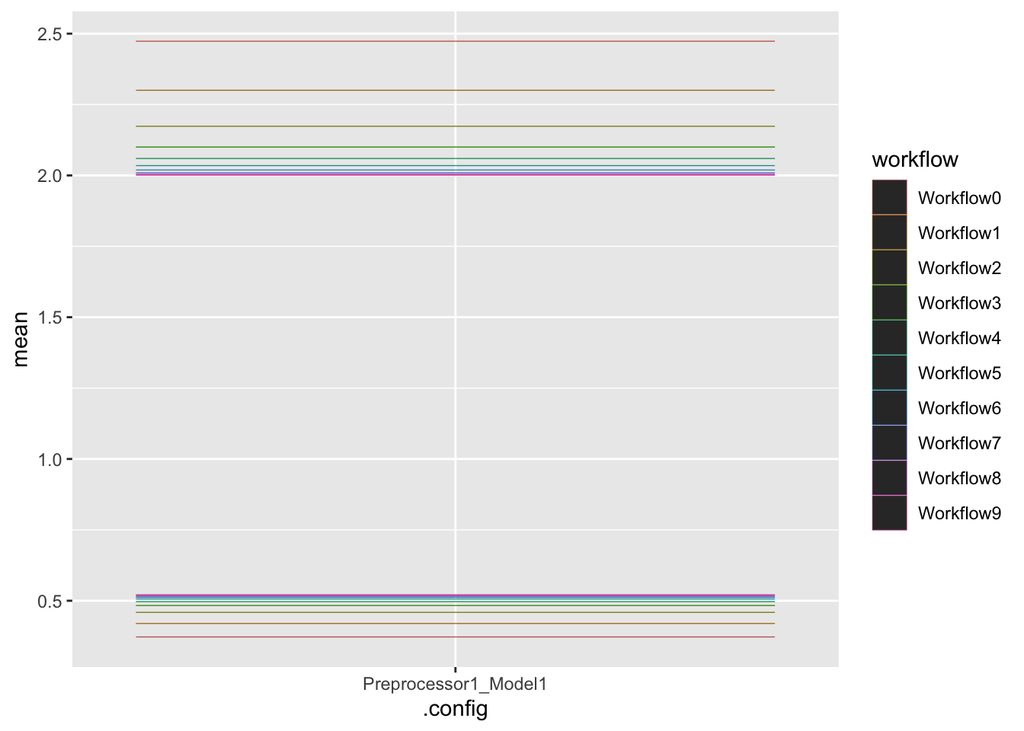

```r
ggplot(all_metric, aes(x =.config, y = mean, color = workflow)) + geom_tile()
```

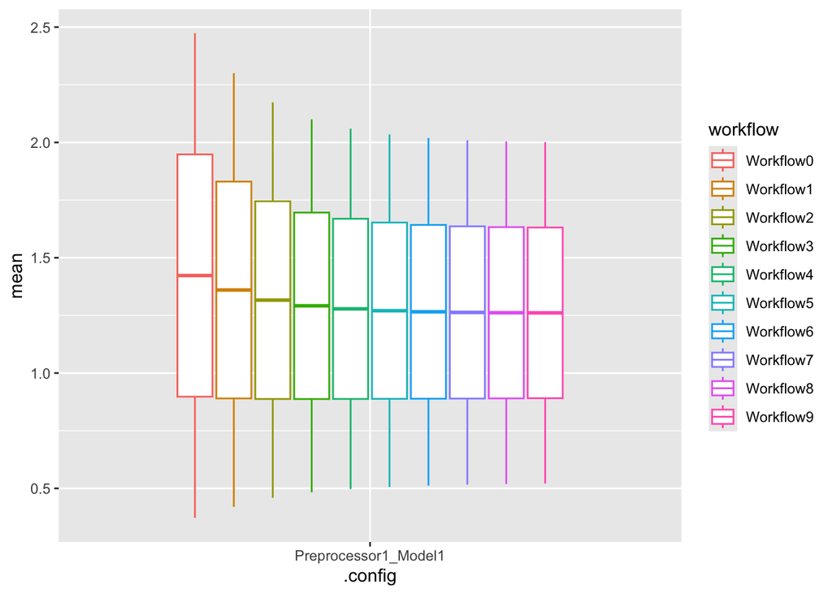

```r
ggplot(all_metric, aes(x =.config, y = mean, color = workflow)) + geom_boxplot()
```

For the graphs the higher values on the y-axis(mean) are RMSE and the lower values are R^2. I.E workflow 9 for example, has the lowest RMSE but the highest R^2 values.

I think that workflow 9 has the best results as it has the highest r^2 value but the lowest RMSE value.